# Association between COVID-19 and Marathon Records

BST 260 Team 11

as of 12/9/2021

## Data Collection Part (Yusuke Yoshikawa)

```r
#### Libraries ####
library(tidyverse)
library(rvest)
library(lubridate)
#if (!require(RCurl)) {install.packages("RCurl", dependencies=TRUE)}
#library(RCurl)
```

```r
#### Men at Tokyo 2020 ####
# URL of Men at Tokyo2020
url_20m <- "https://en.wikipedia.org/wiki/Athletics_at_the_2020_Summer_Olympics_%E2%80%93_Men%27s_marathon"

# Extract all tables in the page
tab <- read_html(url_20m) %>%
  html_nodes("table")
# Table of interest
dat_20m <- tab[[8]] %>%
  html_table()

# Data reshaping
colnames(dat_20m)[1:4] <- c("rank", "athlete", "country", "time")
dat_20m$rank[1:3] <- c(1:3)
dat_20m <- dat_20m %>%
  mutate(rank = ifelse(rank=="—", NA, rank)) %>%
  mutate(sb = ifelse(is.na(rank), NA, 0)) %>%
  mutate(sb = ifelse(Notes %in% c("SB","NR","PB"), 1, sb)) %>%
  mutate(dnf = ifelse(Notes %in% c("DNF","DNS","DSQ"), 1, 0)) %>%
  mutate(time = lubridate::hms(time)) %>%
  select(rank, athlete, country, time, sb, dnf)

# Age data collection
urls <- read_html(url_20m) %>%
  html_nodes("table") %>%
  .[[8]] %>%
  html_nodes("a[href *= '/wiki/' ]") %>% # extract the individual athletes' wikis
  html_attr("href") %>%
  .[!str_detect(.,"Olympics") & !str_detect(., "Bests") & !str_detect(., "conditions") & !str_detect(., "records")] %>%
  paste("https://en.wikipedia.org", ., sep="")

# Extraction of Wiki text function
text_detect <- function(url){
  read_html(url) %>%
    html_nodes("body") %>%
    .[[1]] %>%
    html_text()
}
wiki_text <- sapply(urls, text_detect)

# DOB detection by string processing
dob_detect <- function(string){
  string %>% str_extract(
  "(born \\d{1,2} (January|February|March|April|May|June|July|August|September|October|November|December).\\d{4})|(born (January|February|March|April|May|June|July|August|September|October|November|December) \\d{1,2}. \\d{4})"
  )
}
dobs <- sapply(wiki_text, dob_detect) %>%
  as.character() %>%
  str_replace("born ", "")
dobs_d <- dobs %>% str_extract("\\d{1,2}")
dobs_m <- dobs %>% str_extract("(January|February|March|April|May|June|July|August|September|October|November|December)")
dobs_y <- dobs %>% str_extract("\\d{4}")
dobs <- paste(dobs_y, dobs_m, dobs_d, sep="-") %>% ymd()
dat_20m$dob <- dobs

# Calculate age at Tokyo 2020
if (!require(eeptools)) {install.packages("eeptools", dependencies=TRUE)}
dat_20m <- dat_20m %>%
  mutate(age = eeptools::age_calc(dob, ymd("2021-08-08"), units = "years") %>% floor)

# Sex category
dat_20m$sex <- "Men"
# Game label
dat_20m$olympic <- "Tokyo2020"
```

```r
#### Women at Tokyo 2020 ####
# URL of Women at Tokyo 2020
url_20w <- "https://en.wikipedia.org/wiki/Athletics_at_the_2020_Summer_Olympics_%E2%80%93_Women%27s_marathon"

# Extract all tables in the page
tab <- read_html(url_20w) %>%
  html_nodes("table")
# Table of interest
dat_20w <- tab[[8]] %>%
  html_table()

# Data reshaping
colnames(dat_20w)[1:4] <- c("rank", "athlete", "country", "time")
dat_20w$rank[1:3] <- c(1:3)
dat_20w <- dat_20w %>%
  mutate(rank = ifelse(rank=="–", NA, rank)) %>%
  mutate(sb = ifelse(is.na(rank), NA, 0)) %>%
  mutate(sb = ifelse(Notes %in% c("SB","NR","PB"), 1, sb)) %>%
  mutate(dnf = ifelse(Notes %in% c("DNF","DNS","DSQ"), 1, 0)) %>%
  mutate(time = lubridate::hms(time)) %>%
  select(rank, athlete, country, time, sb, dnf)

# Age data collection
urls <- read_html(url_20w) %>%
  html_nodes("table") %>%
  .[[8]] %>%
  html_nodes("a[href *= '/wiki/' ]") %>% # extract the individual athletes' wikis
  html_attr("href") %>%
  .[!str_detect(.,"Olympics") & !str_detect(., "Bests") & !str_detect(., "conditions") & !str_detect(., "records")] %>%
  paste("https://en.wikipedia.org", ., sep="")

# Extraction of Wiki text by the function above
wiki_text <- sapply(urls, text_detect)

# DOB detection by string processing
dobs <- sapply(wiki_text, dob_detect) %>%
  as.character() %>%
  str_replace("born ", "")
dobs_d <- dobs %>% str_extract("\\d{1,2}")
dobs_m <- dobs %>% str_extract("(January|February|March|April|May|June|July|August|September|October|November|December)")
dobs_y <- dobs %>% str_extract("\\d{4}")
dobs <- paste(dobs_y, dobs_m, dobs_d, sep="-") %>% ymd()
dat_20w$dob <- dobs

# Calculate age at Tokyo 2020
dat_20w <- dat_20w %>%
  mutate(age = eeptools::age_calc(dob, ymd("2021-08-07"), units = "years") %>% floor)

# Sex category
dat_20w$sex <- "Women"
# Game label
dat_20w$olympic <- "Tokyo2020"
```

```r
#### Men at Rio 2016 ####
# URL of Men at Rio 2016
url_16m <- "https://en.wikipedia.org/wiki/Athletics_at_the_2016_Summer_Olympics_%E2%80%93_Men%27s_marathon"

# Extract all tables in the page
tab <- read_html(url_16m) %>%
  html_nodes("table")
# Table of interest
dat_16m <- tab[[6]] %>%
  html_table()

# Data reshaping
colnames(dat_16m)[1:4] <- c("rank", "athlete", "country", "time")
dat_16m$rank[1:3] <- c(1:3)
dat_16m <- dat_16m %>%
  mutate(rank = ifelse(rank=="—", NA, rank)) %>%
  mutate(sb = ifelse(is.na(rank), NA, 0)) %>%
  mutate(sb = ifelse(Notes %in% c("SB","NR","PB"), 1, sb)) %>%
  mutate(dnf = ifelse(time=="DNF" | Notes %in% c("DNF","DNS","DSQ"), 1, 0)) %>%
  mutate(time = ifelse(dnf==1, NA, time)) %>%
  mutate(time = lubridate::hms(time)) %>%
  select(rank, athlete, country, time, sb, dnf)

# Age data collection
urls <- read_html(url_16m) %>%
  html_nodes("table") %>%
  .[[6]] %>%
  html_nodes("a[href *= '/wiki/' ]") %>% # extract the individual athletes' wikis
  html_attr("href") %>%
  .[!str_detect(.,"Olympics") & !str_detect(., "Bests") & !str_detect(., "conditions") & !str_detect(., "records")] %>%
  paste("https://en.wikipedia.org", ., sep="")

# Extraction of Wiki text
wiki_text <- sapply(urls, text_detect)

# DOB detection by string processing
dobs <- sapply(wiki_text, dob_detect) %>%
  as.character() %>%
  str_replace("born ", "")
dobs_d <- dobs %>% str_extract("\\d{1,2}")
dobs_m <- dobs %>% str_extract("(January|February|March|April|May|June|July|August|September|October|November|December)")
dobs_y <- dobs %>% str_extract("\\d{4}")
dobs <- paste(dobs_y, dobs_m, dobs_d, sep="-") %>% ymd()
dat_16m$dob <- dobs

# Calculate age at Rio 2016
dat_16m <- dat_16m %>%
  mutate(age = eeptools::age_calc(dob, ymd("2016-08-21"), units = "years") %>% floor)

# Sex category
dat_16m$sex <- "Men"
# Game label
dat_16m$olympic <- "Rio2016"
```

```r
#### Women at Rio 2016 ####
# URL of Women at Rio 2016
url_16w <- "https://en.wikipedia.org/wiki/Athletics_at_the_2016_Summer_Olympics_%E2%80%93_Women%27s_marathon"

# Extract all tables in the page
tab <- read_html(url_16w) %>%
  html_nodes("table")
# Table of interest
dat_16w <- tab[[6]] %>%
  html_table()

# Data reshaping
colnames(dat_16w)[1:4] <- c("rank", "athlete", "country", "time")
dat_16w$rank[1:3] <- c(1:3)
dat_16w <- dat_16w %>%
  mutate(rank = ifelse(rank=="—", NA, rank)) %>%
  mutate(sb = ifelse(is.na(rank), NA, 0)) %>%
  mutate(sb = ifelse(Notes %in% c("SB","NR","PB"), 1, sb)) %>%
  mutate(dnf = ifelse(time=="DNF" | Notes %in% c("DNF","DNS","DSQ"), 1, 0)) %>%
  mutate(time = ifelse(dnf==1, NA, time)) %>%
  mutate(time = lubridate::hms(time)) %>%
  select(rank, athlete, country, time, sb, dnf)

# Age data collection
urls <- read_html(url_16w) %>%
  html_nodes("table") %>%
  .[[6]] %>%
  html_nodes("a[href *= '/wiki/' ]") %>% # extract the individual athletes' wikis
  html_attr("href") %>%
  .[!str_detect(.,"Olympics") & !str_detect(., "Bests") & !str_detect(., "conditions") & !str_detect(., "records")] %>%
  paste("https://en.wikipedia.org", ., sep="")

# Extraction of Wiki text
wiki_text <- sapply(urls, text_detect)

# DOB detection by string processing
dobs <- sapply(wiki_text, dob_detect) %>%
  as.character() %>%
  str_replace("born ", "")
dobs_d <- dobs %>% str_extract("\\d{1,2}")
dobs_m <- dobs %>% str_extract("(January|February|March|April|May|June|July|August|September|October|November|December)")
dobs_y <- dobs %>% str_extract("\\d{4}")
dobs <- paste(dobs_y, dobs_m, dobs_d, sep="-") %>% ymd()
dobs[128] <- "1980-10-12" %>% ymd()   # missing data (source: https://en.wikipedia.org/wiki/Graciete_Santana)
dat_16w$dob <- dobs

# Calculate age at Rio 2016
dat_16w <- dat_16w %>%
  mutate(age = eeptools::age_calc(dob, ymd("2016-08-14"), units = "years") %>% floor)

# Sex category
dat_16w$sex <- "Women"
# Game label
dat_16w$olympic <- "Rio2016"
```

```r
#### Combine the 4 dataframes ####
dat <- rbind(dat_20m, dat_20w, dat_16m, dat_16w)

#### Rename the countries ####
dat <- dat %>%
  mutate(country = ifelse(country=="Chinese Taipei", "Taiwan", country)) %>%
  mutate(country = ifelse(country=="Democratic Republic of the Congo", "Congo (Kinshasa)", country))
```

```r
#### Lockdown ####
# Source: https://en.m.wikipedia.org/wiki/COVID-19_lockdowns
non_lockdown <- c("Burundi", "Iceland", "Japan", "Nicaragua",
                  "South Korea", "Sweden", "Taiwan", "Tanzania", "Uruguay")
dat <- dat %>%
  mutate(lockdown = ifelse(country %in% non_lockdown, 0, 1))
```

```r
#### Prior attendance at Tokyo ####
prior_attend <- dat %>%
  group_by(athlete) %>%
  filter(n()>1) %>%
  pull(athlete)
dat <- dat %>%
  mutate(prior_attend = ifelse(olympic=="Tokyo2020" & athlete %in% prior_attend, 1, 0))
```

```r
#### COVID-19 cases / population as of July 22, 2021 ####
# COVID-19 cases collected from [Github](https://github.com/CSSEGISandData/COVID-19).
#url <- getURL("https://raw.githubusercontent.com/CSSEGISandData/COVID-19/master/csse_covid_19_data/csse_covid_19_time_series/time_series_covid19_confirmed_global.csv")

url <- "https://raw.githubusercontent.com/CSSEGISandData/COVID-19/master/csse_covid_19_data/csse_covid_19_time_series/time_series_covid19_confirmed_global.csv"
jhu <- read_csv(url) %>%
  dplyr::select(`Province/State`, `Country/Region`, `7/22/21`) %>%
  mutate(`Country/Region2` = ifelse(is.na(`Province/State`), `Country/Region`,
                                    ifelse(`Province/State`=="Hong Kong", "Hong Kong",
                                           `Country/Region`))) %>%
  group_by(`Country/Region2`) %>%
  summarise(case_total = sum(`7/22/21`), .groups="drop") %>%
  rename(country = `Country/Region2`) %>%
  dplyr::select(country, case_total)
```

```r
#### Population/GDP ####

# Read in Johns Hopkins UID lookup table
# Source: https://raw.githubusercontent.com/CSSEGISandData/COVID-19/master/csse_covid_19_data/UID_ISO_FIPS_LookUp_Table.csv
url <- "https://raw.githubusercontent.com/CSSEGISandData/COVID-19/master/csse_covid_19_data/UID_ISO_FIPS_LookUp_Table.csv"
pop <- read_csv(url)

# GDP data #
# Read in GDP data on WORLD BANK
# Source: https://api.worldbank.org/v2/en/indicator/NY.GDP.MKTP.CD?downloadformat=csv
url <- "https://api.worldbank.org/v2/en/indicator/NY.GDP.MKTP.CD?downloadformat=csv"
gdp <- read_csv("API_NY.GDP.MKTP.CD_DS2_en_csv_v2_3263806.csv")

# Join the population and the GDP data
temp <- left_join(pop %>% subset(is.na(Province_State)),
                  gdp %>%
                    rename(iso3 = `Country Code`,
                           gdp2016 = `2016`,
                           gdp2017 = `2017`,
                           gdp2018 = `2018`,
                           gdp2019 = `2019`,
                           gdp2020 = `2020`) %>%
                    dplyr::select(iso3, `Country Name`, gdp2016:gdp2020),
                  by = "iso3")

jhu <- left_join(jhu,
                 temp %>% rename(country = Country_Region),
                 by="country")

jhu <- jhu %>%
  mutate(case_pp = case_total/Population) %>%
  dplyr::select(country, case_pp, gdp2016:gdp2020)

# Reclassify discrepant country names
jhu <- jhu %>%
  mutate(country = ifelse(country %in% dat$country, country,
                          case_when(country == "Taiwan*" ~ "Taiwan",
                                    country == "Czechia" ~ "Czech Republic",
                                    country == "Democratic Republic of the Congo" ~ "Congo",
                                    country == "United Kingdom" ~ "Great Britain",
                                    country == "Korea, South" ~ "South Korea",
                                    country == "US" ~ "United States")))
```

```r
#### join the datasets (dat+jhu+pop+gdp) ####
# No data on cases: North Korea, Palestine, Pueruto Rico, Refugee Olympic Team
dat <- left_join(dat, jhu, by="country")
```

```r
#### Continent ####
# URL of continent category
url <- "https://www.newworldencyclopedia.org/entry/list_of_countries_by_continent"

# Extract all tables in the page
tab <- read_html(url) %>%
  html_nodes("table")
# Africa
africa <- tab[[1]] %>%
  html_table() %>%
  .[,c(1,3)]
africa <- paste0(africa[,1], africa[,2], "South Sudan") # add discrepant country name
# Asia
asia <- tab[[2]] %>%
  html_table() %>%
  .[,c(1,3)]
asia <- paste0(asia[,1], asia[,2], "Taiwan") # add discrepant country name
# Europe
europe <- tab[[3]] %>%
  html_table() %>%
  .[,c(1,3)]
europe <- paste0(europe[,1], europe[,2], "Great Britain") # add discrepant country name
# North America
n_america <- tab[[4]] %>%
  html_table() %>%
  .[,c(1,3)]
n_america <- paste0(n_america[,1], n_america[,2])
# South America
s_america <- tab[[5]] %>%
  html_table() %>%
  .[,c(1,3)]
s_america <- paste0(s_america[,1], s_america[,2])
# Oceania
oceania <- tab[[6]] %>%
  html_table() %>%
  .[,c(1,3)]
oceania <- paste0(oceania[,1], oceania[,2])

dat <- dat %>%
  mutate(continent = case_when(str_detect(africa, country) ~ "Africa",
                               country=="Congo (Kinshasa)" ~ "Africa", # add discrepant country name
                               str_detect(asia, country) ~ "Asia",
                               str_detect(europe, country) ~ "Europe",
                               str_detect(n_america, country) ~ "North America",
                               str_detect(s_america, country) ~ "South America",
                               str_detect(oceania, country) ~ "Oceania"))

# time conversion into seconds for analyses
dat <- dat %>%
  mutate(time_sec = period_to_seconds(time)) %>%
  select(rank:time, time_sec, sb:last_col())
```

```r
#### Final dataset ####
rm(list = ls()[!ls()=="dat"])
dat %>% slice(1:10) %>% knitr::kable()
```

| rank | athlete | country | time | time_sec | sb | dnf | dob | age | sex | olympic | lockdown | prior_attend | case_pp | gdp2016 | gdp2017 | gdp2018 | gdp2019 | gdp2020 | continent |
| --- | --- | --- | --- | --- | --- | --- | --- | --- | --- | --- | --- | --- | --- | --- | --- | --- | --- | --- | --- |
| 1 | Eliud Kipchoge | Kenya | 2H 8M 38S | 7718 | 0 | 0 | 1984-11-05 | 36 | Men | Tokyo2020 | 1 | 1 | 0.0036285 | 6.918876e+10 | 7.896500e+10 | 8.777858e+10 | 9.550309e+10 | 9.884294e+10 | Africa |
| 2 | Abdi Nageeye | Netherlands | 2H 9M 58S | 7798 | 1 | 0 | 1989-03-02 | 32 | Men | Tokyo2020 | 1 | 1 | 0.1083166 | 7.835280e+11 | 8.318100e+11 | 9.135970e+11 | 9.101940e+11 | 9.138650e+11 | Europe |
| 3 | Bashir Abdi | Belgium | 2H 10M 0S | 7800 | 1 | 0 | 1989-02-10 | 32 | Men | Tokyo2020 | 1 | 0 | 0.0967716 | 4.757400e+11 | 5.015230e+11 | 5.434110e+11 | 5.332550e+11 | 5.153320e+11 | Europe |
| 4 | Lawrence Cherono | Kenya | 2H 10M 2S | 7802 | 1 | 0 | 1988-08-07 | 33 | Men | Tokyo2020 | 1 | 0 | 0.0036285 | 6.918876e+10 | 7.896500e+10 | 8.777858e+10 | 9.550309e+10 | 9.884294e+10 | Africa |
| 5 | Ayad Lamdassem | Spain | 2H 10M 16S | 7816 | 1 | 0 | 1981-10-11 | 39 | Men | Tokyo2020 | 1 | 0 | 0.0908839 | 1.232080e+12 | 1.309300e+12 | 1.420300e+12 | 1.393050e+12 | 1.281480e+12 | Europe |
| 6 | Suguru Osako | Japan | 2H 10M 41S | 7841 | 1 | 0 | 1991-05-23 | 30 | Men | Tokyo2020 | 0 | 0 | 0.0067817 | 5.003680e+12 | 4.930840e+12 | 5.036890e+12 | 5.148780e+12 | 4.975420e+12 | Asia |
| 7 | Alphonce Simbu | Tanzania | 2H 11M 35S | 7895 | 1 | 0 | 1992-02-14 | 29 | Men | Tokyo2020 | 0 | 1 | 0.0000085 | 4.977402e+10 | 5.332063e+10 | 5.700371e+10 | 6.113687e+10 | 6.240975e+10 | Africa |
| 8 | Galen Rupp | United States | 2H 11M 41S | 7901 | 1 | 0 | 1986-05-08 | 35 | Men | Tokyo2020 | 1 | 1 | 0.1043182 | 1.874510e+13 | 1.954300e+13 | 2.061190e+13 | 2.143320e+13 | 2.093660e+13 | North America |
| 9 | Othmane El Goumri | Morocco | 2H 11M 58S | 7918 | 0 | 0 | 1992-05-28 | 29 | Men | Tokyo2020 | 1 | 0 | 0.0153820 | 1.033120e+11 | 1.096830e+11 | 1.180960e+11 | 1.197000e+11 | 1.128710e+11 | Africa |
| 10 | Koen Naert | Belgium | 2H 12M 13S | 7933 | 1 | 0 | 1989-09-03 | 31 | Men | Tokyo2020 | 1 | 1 | 0.0967716 | 4.757400e+11 | 5.015230e+11 | 5.434110e+11 | 5.332550e+11 | 5.153320e+11 | Europe |

- `rank`: rank at each Olympic game
- `athlete`: athlete names
- `country`: country from which the athlete is
- `time`: records at each Olympic game
- `time_sec`: records at each Olympic game in seconds
- `sb`: season best of the athlete; including national record and personal pest
- `dnf`: did not finish; including did not start and disqualified
- `dob`: date of birth
- `age`: age (years) at the time of each Olympic game
- `sex`: sex category
- `olympic`: Olympic game name
- `case_pp`: total case per population of the athlete country as of July 22, 2021
- `gdp2016:2020`: GDP from 2016 to 2020
- `continent`: continent from which the athlete is
- `lockdown`: yes if the country from which the athletes is implemented lockdown
- `prior_attend`: prior attendance of Tokyo 2020 athletes at Rio 2016 (athletes at Rio 2016 are all “no”)

# Machine learning: model building & comparison (Mariko Ando)

After we investigated the athletes’ performance by comparing 2016 vs 2020, we also got interested in building models that could classify the athletes’ performance during the COVID-19 pandemic by using 2020 Olympic data. By using the best model, we can classify the athletes’ performance in the future Olympic Games during the COVID-19 pandemic, which is interesting to athletes and some others. We included the COVID-19 severity, continent where the athletes came from, age, gdp in 2020 of the country where the athletes came from, and prior attendance at Rio 2016 in the model for classifying the performance (1: worse record, 0: better record). As male athletes ran much faster than female athletes, we decided to separately build models for males and females.

We compared six models including logistic regression, Naive Bayes, knn, QDA, LDA, and Trees in terms of model accuracy and discrimination (by AUC). Table 1 shows the summary of model comparison for males, and table 2 shows the summary of model comparison for females. .

## Analysis for Men’s records

```r
dat=as.data.frame(dat)
```

```r
# library
library(tidyverse)
library(rvest)
library(lubridate)
library(broom)
library(caret)
```

```r
library(ggplot2)
library(e1071)
library(MASS)
library(rpart)
library(randomForest)
library(pROC)
library(adabag)
library(splitstackshape)
library(knitr)
```

```r
# filter: 2020, Men, finish race
# I created a dataset, datsecond, just including male athletes who finished race in the Tokyo 2020 game.
# As men ran much faster than women, we separately analyzed the male and female datasets.
datsecond <- dat %>% filter(dnf==0 & olympic=="Tokyo2020" & sex=="Men") %>% dplyr::select(time_sec, case_pp, continent, age, gdp2020, prior_attend)
summary(datsecond)
```

```
##     time_sec       case_pp           continent              age
##  Min.   :7718   Min.   :0.0000085   Length:76          Min.   :23.00
##  1st Qu.:8108   1st Qu.:0.0067817   Class :character   1st Qu.:29.00
##  Median :8252   Median :0.0465300   Mode  :character   Median :31.00
##  Mean   :8324   Mean   :0.0515946                      Mean   :31.22
##  3rd Qu.:8498   3rd Qu.:0.0918954                      3rd Qu.:33.25
##  Max.   :9876   Max.   :0.1576326                      Max.   :44.00
##                 NA's   :1
##     gdp2020           prior_attend
##  Min.   :1.845e+09   Min.   :0.00
##  1st Qu.:2.064e+11   1st Qu.:0.00
##  Median :5.153e+11   Median :0.00
##  Mean   :2.483e+12   Mean   :0.25
##  3rd Qu.:1.765e+12   3rd Qu.:0.25
##  Max.   :2.094e+13   Max.   :1.00
##  NA's   :5
```

```r
# convert binary and categorical data as factor
datsecond <- datsecond %>%
  mutate(continent=as.factor(continent), prior_attend=as.factor(prior_attend))

# omit rows with NA
# Here, we decided to conduct complete case analysis.
datsecond<-datsecond %>% filter(!is.na(time_sec))%>% filter(!is.na(case_pp))%>% filter(!is.na(continent))%>% filter(!is.na(age))%>% filter(!is.na(gdp2020))%>% filter(!is.na(prior_attend))
summary(datsecond)
```

```
##     time_sec       case_pp                  continent       age
##  Min.   :7718   Min.   :8.520e-06   Africa       :15   Min.   :24.00
##  1st Qu.:8116   1st Qu.:1.108e-02   Asia         :12   1st Qu.:29.00
##  Median :8307   Median :5.319e-02   Europe       :23   Median :31.00
##  Mean   :8339   Mean   :5.220e-02   North America:11   Mean   :31.42
##  3rd Qu.:8516   3rd Qu.:9.190e-02   Oceania      : 4   3rd Qu.:33.50
##  Max.   :9876   Max.   :1.083e-01   South America: 6   Max.   :44.00
##     gdp2020          prior_attend
##  Min.   :1.845e+09   0:52
##  1st Qu.:2.064e+11   1:19
##  Median :5.153e+11
##  Mean   :2.483e+12
##  3rd Qu.:1.765e+12
##  Max.   :2.094e+13
```

```r
# Based on the calculation by Yi-Ting, one member of our team, we used 8239 sec as a cutpoint for male athletes. We defined time_sec<8239 as better record (outcome=0) and time_sec>=8239 as worse record (outcome=1).

cut <- 8239
datsecond<-datsecond%>%
  mutate(timebinary=ifelse(time_sec<cut,0,1)) %>%
  mutate(timebinary=as.factor(timebinary))
summary(datsecond)
```

```
##     time_sec       case_pp                  continent       age
##  Min.   :7718   Min.   :8.520e-06   Africa       :15   Min.   :24.00
##  1st Qu.:8116   1st Qu.:1.108e-02   Asia         :12   1st Qu.:29.00
##  Median :8307   Median :5.319e-02   Europe       :23   Median :31.00
##  Mean   :8339   Mean   :5.220e-02   North America:11   Mean   :31.42
##  3rd Qu.:8516   3rd Qu.:9.190e-02   Oceania      : 4   3rd Qu.:33.50
##  Max.   :9876   Max.   :1.083e-01   South America: 6   Max.   :44.00
##     gdp2020          prior_attend timebinary
##  Min.   :1.845e+09   0:52         0:32
##  1st Qu.:2.064e+11   1:19         1:39
##  Median :5.153e+11
##  Mean   :2.483e+12
##  3rd Qu.:1.765e+12
##  Max.   :2.094e+13
```

```r
# split train (70%), test (30%)
# We used stratified function to split the dataset into training and testing datasets because we wanted to get almost equal distribution of outcome in both datasets. After splitting, the training set included 49 athletes while the testing set included 22 athletes.
set.seed(1)
x <- stratified(datsecond, "timebinary", 0.70, keep.rownames = TRUE)
train_set <- x %>% dplyr::select(-rn)
train_index <- as.numeric(x$rn)
test_set <- datsecond[-train_index,]
dim(train_set)
```

```
## [1] 49  7
```

```r
dim(test_set)
```

```
## [1] 22  7
```

```r
# Here, we decided to build six models to predict the worse record.
# Six models include logistic regression, Naive Bayes, knn, QDA, LDA, and Trees. The model included COVID-19 severity (continuous) defined as the case number per population, continent (categorical), age (continuous), gdp2020 (continuous), and prior_attend (binary).
#In each model, we will report accuracy, sensitivity, and specificity.

# Model1: logistic regression
# accuracy = 0.5000, sensitivity = 0.5833, specificity = 0.4000
glm_fit <- glm(timebinary ~ case_pp + continent + age + gdp2020 + prior_attend, data = train_set, family = "binomial")
p_hat_logit<-predict(glm_fit, newdata=test_set, type="response")
y_hat_logit <- factor(ifelse(p_hat_logit > 0.5, 1, 0))
confusionMatrix(as.factor(y_hat_logit), reference = test_set$timebinary,positive="1")
```

```
## Confusion Matrix and Statistics
##
##           Reference
## Prediction 0 1
##          0 4 5
##          1 6 7
##
##                Accuracy : 0.5
##                  95% CI : (0.2822, 0.7178)
##     No Information Rate : 0.5455
##     P-Value [Acc > NIR] : 0.7404
##
##                   Kappa : -0.0168
##
##  Mcnemar's Test P-Value : 1.0000
##
##             Sensitivity : 0.5833
##             Specificity : 0.4000
##          Pos Pred Value : 0.5385
##          Neg Pred Value : 0.4444
##              Prevalence : 0.5455
##          Detection Rate : 0.3182
##    Detection Prevalence : 0.5909
##       Balanced Accuracy : 0.4917
##
##        'Positive' Class : 1
##
```

```r
# Model2: Naive Bayes
# accuracy = 0.5909, sensitivity = 0.7500, specificity = 0.4000
nb_fit <- naiveBayes(timebinary ~ case_pp + continent + age + gdp2020 + prior_attend, data = train_set)
p_hat_nb<-predict(nb_fit, newdata=test_set, type="raw")[,2]
y_hat_nb<-factor(ifelse(p_hat_nb>0.5,1,0))
confusionMatrix(data=as.factor(y_hat_nb),reference=test_set$timebinary,positive="1")
```

```
## Confusion Matrix and Statistics
##
##           Reference
## Prediction 0 1
##          0 4 3
##          1 6 9
##
##                Accuracy : 0.5909
##                  95% CI : (0.3635, 0.7929)
##     No Information Rate : 0.5455
##     P-Value [Acc > NIR] : 0.418
##
##                   Kappa : 0.1538
##
##  Mcnemar's Test P-Value : 0.505
##
##             Sensitivity : 0.7500
##             Specificity : 0.4000
##          Pos Pred Value : 0.6000
##          Neg Pred Value : 0.5714
##              Prevalence : 0.5455
##          Detection Rate : 0.4091
##    Detection Prevalence : 0.6818
##       Balanced Accuracy : 0.5750
##
##        'Positive' Class : 1
##
```

```r
# Model3: knn
# For the value of k, we chose the number closest to the squared root of the sample size of the training set, which was 7.
# accuracy =  0.5000, sensitivity = 0.5833, specificity = 0.4000
knn_fit<-knn3(timebinary ~ case_pp + continent + age  + gdp2020 + prior_attend, data = train_set, k=7)
p_hat_knn<-predict(knn_fit,newdata=test_set)[,2]
y_hat_knn<-factor(ifelse(p_hat_knn>0.5,1,0))
confusionMatrix(data=as.factor(y_hat_knn),reference=test_set$timebinary,positive="1")
```

```
## Confusion Matrix and Statistics
##
##           Reference
## Prediction 0 1
##          0 4 5
##          1 6 7
##
##                Accuracy : 0.5
##                  95% CI : (0.2822, 0.7178)
##     No Information Rate : 0.5455
##     P-Value [Acc > NIR] : 0.7404
##
##                   Kappa : -0.0168
##
##  Mcnemar's Test P-Value : 1.0000
##
##             Sensitivity : 0.5833
##             Specificity : 0.4000
##          Pos Pred Value : 0.5385
##          Neg Pred Value : 0.4444
##              Prevalence : 0.5455
##          Detection Rate : 0.3182
##    Detection Prevalence : 0.5909
##       Balanced Accuracy : 0.4917
##
##        'Positive' Class : 1
##
```

```r
# Model4: QDA
# accuracy = 0.5000 , sensitivity = 0.6667, specificity = 0.3000
set.seed(1)
qda_fit <- qda(timebinary ~ case_pp + continent + age + gdp2020 + prior_attend, data = train_set)
p_hat_qda <- predict(qda_fit,newdata=test_set)$posterior[,2]
y_hat_qda <- factor(ifelse(p_hat_qda>0.5,1,0))
confusionMatrix(data=as.factor(y_hat_qda),reference=test_set$timebinary,positive="1")
```

```
## Confusion Matrix and Statistics
##
##           Reference
## Prediction 0 1
##          0 3 4
##          1 7 8
##
##                Accuracy : 0.5
##                  95% CI : (0.2822, 0.7178)
##     No Information Rate : 0.5455
##     P-Value [Acc > NIR] : 0.7404
##
##                   Kappa : -0.0342
##
##  Mcnemar's Test P-Value : 0.5465
##
##             Sensitivity : 0.6667
##             Specificity : 0.3000
##          Pos Pred Value : 0.5333
##          Neg Pred Value : 0.4286
##              Prevalence : 0.5455
##          Detection Rate : 0.3636
##    Detection Prevalence : 0.6818
##       Balanced Accuracy : 0.4833
##
##        'Positive' Class : 1
##
```

```r
# Model5: LDA
# accuracy = 0.5000, sensitivity = 0.5833, specificity = 0.4000
set.seed(1)
lda_fit <- lda(timebinary ~ case_pp + continent + age + gdp2020 + prior_attend, data = train_set)
p_hat_lda <- predict(lda_fit,newdata=test_set)$posterior[,2]
y_hat_lda <- factor(ifelse(p_hat_lda>0.5,1,0))
confusionMatrix(data=as.factor(y_hat_lda),reference=test_set$timebinary,positive="1")
```

```
## Confusion Matrix and Statistics
##
##           Reference
## Prediction 0 1
##          0 4 5
##          1 6 7
##
##                Accuracy : 0.5
##                  95% CI : (0.2822, 0.7178)
##     No Information Rate : 0.5455
##     P-Value [Acc > NIR] : 0.7404
##
##                   Kappa : -0.0168
##
##  Mcnemar's Test P-Value : 1.0000
##
##             Sensitivity : 0.5833
##             Specificity : 0.4000
##          Pos Pred Value : 0.5385
##          Neg Pred Value : 0.4444
##              Prevalence : 0.5455
##          Detection Rate : 0.3182
##    Detection Prevalence : 0.5909
##       Balanced Accuracy : 0.4917
##
##        'Positive' Class : 1
##
```

```r
# Model6: Decision trees
# accuracy = 0.5455, sensitivity = 0.5833, specificity = 0.5000
set.seed(1)
tree_fit <- rpart(timebinary ~ case_pp + continent + age + gdp2020 + prior_attend, data = train_set)
p_hat_tree <- predict(tree_fit,newdata=test_set)[,2]
y_hat_tree <- factor(ifelse(p_hat_tree>0.5,1,0))
confusionMatrix(data=as.factor(y_hat_tree),reference=test_set$timebinary,positive="1")
```

```
## Confusion Matrix and Statistics
##
##           Reference
## Prediction 0 1
##          0 5 5
##          1 5 7
##
##                Accuracy : 0.5455
##                  95% CI : (0.3221, 0.7561)
##     No Information Rate : 0.5455
##     P-Value [Acc > NIR] : 0.5869
##
##                   Kappa : 0.0833
##
##  Mcnemar's Test P-Value : 1.0000
##
##             Sensitivity : 0.5833
##             Specificity : 0.5000
##          Pos Pred Value : 0.5833
##          Neg Pred Value : 0.5000
##              Prevalence : 0.5455
##          Detection Rate : 0.3182
##    Detection Prevalence : 0.5455
##       Balanced Accuracy : 0.5417
##
##        'Positive' Class : 1
##
```

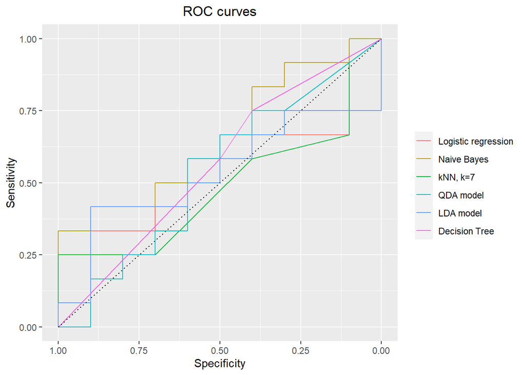

```r
# plot ROC curve
# Here, we compare ROC curves and AUC to see which model has a better discrimination.

roc_logit<-roc(test_set$timebinary,p_hat_logit)
roc_nb<-roc(test_set$timebinary,p_hat_nb)
roc_knn<-roc(test_set$timebinary,p_hat_knn)
roc_qda<-roc(test_set$timebinary,p_hat_qda)
roc_lda<-roc(test_set$timebinary,p_hat_lda)
roc_tree<-roc(test_set$timebinary,p_hat_tree)
ggroc(list("Logistic regression"=roc_logit,"Naive Bayes"=roc_nb,"kNN, k=7"=roc_knn, "QDA model"=roc_qda,"LDA model"=roc_lda, "Decision Tree"=roc_tree))+
  theme(legend.title=element_blank())+
  geom_segment(aes(x=1, xend=0,y=0,yend=1),color="black",linetype="dotted")+
  ggtitle("ROC curves") +
  xlab("Specificity")+
  ylab("Sensitivity")+
  theme(plot.title = element_text(hjust = 0.5))
```

```r
#Naive Bayes model has the highest AUC.
auc(roc_logit)
```

```
## Area under the curve: 0.4917
```

```r
auc(roc_nb)
```

```
## Area under the curve: 0.65
```

```r
auc(roc_knn)
```

```
## Area under the curve: 0.4833
```

```r
auc(roc_qda)
```

```
## Area under the curve: 0.5375
```

```r
auc(roc_lda)
```

```
## Area under the curve: 0.5333
```

```r
auc(roc_tree)
```

```
## Area under the curve: 0.5625
```

```r
#Table for men's models
Men_models <- c("Logistic", "Naive Bayes", "kNN, k=7", "QDA", "LDA", "Trees")
Accuracy <- c("0.5000", "0.5909", "0.5000", "0.5000", "0.5000", "0.5455")
Sensitivity <- c("0.5833", "0.7500", "0.5833", "0.6667", "0.5833", "0.5833")
Specificity <- c("0.4000", "0.4000", "0.4000", "0.3000", "0.4000", "0.5000")
PPV <- c("0.5385", "0.6000", "0.5385", "0.5333", "0.5385", "0.5833")
NPV <- c("0.4444", "0.5714", "0.4444", "0.4286", "0.4444", "0.5000")
AUC <- c("0.4917", "0.6500", "0.4833", "0.5375", "0.5333", "0.5625")
male_df <- data.frame(Men_models, Accuracy, Sensitivity, Specificity, PPV, NPV, AUC)

male_df2 <- head(male_df)
knitr::kable(male_df2, col.names = gsub("[.]", " ", names(male_df)), caption = "Table 1: Model comparison for male athletes")
```

Table 1: Model comparison for male athletes

| Men_models | Accuracy | Sensitivity | Specificity | PPV | NPV | AUC |
| --- | --- | --- | --- | --- | --- | --- |
| Logistic | 0.5000 | 0.5833 | 0.4000 | 0.5385 | 0.4444 | 0.4917 |
| Naive Bayes | 0.5909 | 0.7500 | 0.4000 | 0.6000 | 0.5714 | 0.6500 |
| kNN, k=7 | 0.5000 | 0.5833 | 0.4000 | 0.5385 | 0.4444 | 0.4833 |
| QDA | 0.5000 | 0.6667 | 0.3000 | 0.5333 | 0.4286 | 0.5375 |
| LDA | 0.5000 | 0.5833 | 0.4000 | 0.5385 | 0.4444 | 0.5333 |
| Trees | 0.5455 | 0.5833 | 0.5000 | 0.5833 | 0.5000 | 0.5625 |

##### (Summary) According to the outputs, Naive Bayes model showed the highest accuracy and the highest AUC (i.e., best discrimination). Then, Naive Bayes model could be the best model to classify male athletes’ performance in the future Olympic Games during a similar pandemic. However, as the current dataset included very small number of samples, we should ideally repeat similar analyses by using bootstrapping methods or other datasets with larger sample size of athletes and compare the models.

## Analysis for women’s records

```r
# filter: 2020, Women, finish race
# I created a dataset, datsecondfemale, just including female athletes who finished race in the Tokyo 2020 game.

datsecondfemale <- dat %>% filter(dnf==0 & olympic=="Tokyo2020" & sex=="Women") %>% dplyr::select(time_sec, case_pp, continent, age, gdp2020, prior_attend)
summary(datsecondfemale)
```

```
##     time_sec        case_pp           continent              age
##  Min.   : 8840   Min.   :8.520e-06   Length:73          Min.   :24.00
##  1st Qu.: 9194   1st Qu.:6.782e-03   Class :character   1st Qu.:28.00
##  Median : 9339   Median :4.632e-02   Mode  :character   Median :31.00
##  Mean   : 9473   Mean   :5.392e-02                      Mean   :31.18
##  3rd Qu.: 9604   3rd Qu.:9.088e-02                      3rd Qu.:34.00
##  Max.   :10990   Max.   :1.576e-01                      Max.   :44.00
##
##     gdp2020           prior_attend
##  Min.   :1.551e+09   Min.   :0.0000
##  1st Qu.:1.103e+11   1st Qu.:0.0000
##  Median :5.411e+11   Median :0.0000
##  Mean   :2.164e+12   Mean   :0.1507
##  3rd Qu.:1.644e+12   3rd Qu.:0.0000
##  Max.   :2.094e+13   Max.   :1.0000
##  NA's   :2
```

```r
# convert binary and categorical data as factor
datsecondfemale <- datsecondfemale %>%
  mutate(continent=as.factor(continent), prior_attend=as.factor(prior_attend))

# omit rows with NA
#Here, we decided to conduct complete case analysis again.
datsecondfemale<-datsecondfemale %>% filter(!is.na(time_sec))%>% filter(!is.na(case_pp))%>% filter(!is.na(continent))%>% filter(!is.na(age))%>% filter(!is.na(gdp2020))%>% filter(!is.na(prior_attend))
summary(datsecondfemale)
```

```
##     time_sec        case_pp                  continent       age
##  Min.   : 8840   Min.   :8.520e-06   Africa       :11   Min.   :24.00
##  1st Qu.: 9194   1st Qu.:6.782e-03   Asia         :13   1st Qu.:27.50
##  Median : 9339   Median :4.632e-02   Europe       :30   Median :31.00
##  Mean   : 9481   Mean   :5.319e-02   North America: 7   Mean   :31.23
##  3rd Qu.: 9607   3rd Qu.:8.955e-02   Oceania      : 4   3rd Qu.:34.00
##  Max.   :10990   Max.   :1.561e-01   South America: 6   Max.   :44.00
##     gdp2020          prior_attend
##  Min.   :1.551e+09   0:60
##  1st Qu.:1.103e+11   1:11
##  Median :5.411e+11
##  Mean   :2.164e+12
##  3rd Qu.:1.644e+12
##  Max.   :2.094e+13
```

```r
# Based on the calculation by Yi-Ting, one member of our team, we used 9339 sec as a cutpoint for female athletes. We defined time_sec<9339 as better record (outcome=0) and time_sec>=9339 as worse record (outcome=1).

cut_female <- 9339
datsecondfemale<-datsecondfemale%>%
   mutate(timebinary=ifelse(time_sec<cut_female,0,1)) %>%
   mutate(timebinary=as.factor(timebinary))
summary(datsecondfemale)
```

```
##     time_sec        case_pp                  continent       age
##  Min.   : 8840   Min.   :8.520e-06   Africa       :11   Min.   :24.00
##  1st Qu.: 9194   1st Qu.:6.782e-03   Asia         :13   1st Qu.:27.50
##  Median : 9339   Median :4.632e-02   Europe       :30   Median :31.00
##  Mean   : 9481   Mean   :5.319e-02   North America: 7   Mean   :31.23
##  3rd Qu.: 9607   3rd Qu.:8.955e-02   Oceania      : 4   3rd Qu.:34.00
##  Max.   :10990   Max.   :1.561e-01   South America: 6   Max.   :44.00
##     gdp2020          prior_attend timebinary
##  Min.   :1.551e+09   0:60         0:35
##  1st Qu.:1.103e+11   1:11         1:36
##  Median :5.411e+11
##  Mean   :2.164e+12
##  3rd Qu.:1.644e+12
##  Max.   :2.094e+13
```

```r
# split train (70%), test (30%)
# We used stratified function to split the dataset into training and testing datasets because we wanted to get almost equal distribution of outcome in both datasets. After splitting, the training set included 49 athletes while the testing set included 22 athletes.
set.seed(1)
x_female <- stratified(datsecondfemale, "timebinary", 0.70, keep.rownames = TRUE)
train_set_female <- x_female %>% dplyr::select(-rn)
train_index_female <- as.numeric(x_female$rn)
test_set_female <- datsecondfemale[-train_index_female,]
dim(train_set_female)
```

```
## [1] 49  7
```

```r
dim(test_set_female)
```

```
## [1] 22  7
```

```r
# Here, we decided to build six models to predict the worse record.
# Six models include logistic regression, Naive Bayes, knn, QDA, LDA, and Trees. The model included COVID-19 severity (continuous) defined as the case number per population, continent (categorical), age (continuous), gdp2020 (continuous), and prior_attend (binary).
#In each model, we will report accuracy, sensitivity, and specificity.

# Model1: logistic regression
# accuracy = 0.5909, sensitivity = 0.7273 , specificity = 0.4545
glm_fit_female <- glm(timebinary ~ case_pp + continent + age + gdp2020 + prior_attend, data = train_set_female, family = "binomial")
p_hat_logit_female<-predict(glm_fit_female, newdata=test_set_female, type="response")
y_hat_logit_female <- factor(ifelse(p_hat_logit_female > 0.5, 1, 0))
confusionMatrix(as.factor(y_hat_logit_female), reference = test_set_female$timebinary,positive="1")
```

```
## Confusion Matrix and Statistics
##
##           Reference
## Prediction 0 1
##          0 5 3
##          1 6 8
##
##                Accuracy : 0.5909
##                  95% CI : (0.3635, 0.7929)
##     No Information Rate : 0.5
##     P-Value [Acc > NIR] : 0.2617
##
##                   Kappa : 0.1818
##
##  Mcnemar's Test P-Value : 0.5050
##
##             Sensitivity : 0.7273
##             Specificity : 0.4545
##          Pos Pred Value : 0.5714
##          Neg Pred Value : 0.6250
##              Prevalence : 0.5000
##          Detection Rate : 0.3636
##    Detection Prevalence : 0.6364
##       Balanced Accuracy : 0.5909
##
##        'Positive' Class : 1
##
```

```r
# Model2: Naive Bayes
# accuracy = 0.3636, sensitivity = 0.4545, specificity = 0.2727
nb_fit_female <- naiveBayes(timebinary ~ case_pp + continent + age + gdp2020 + prior_attend, data = train_set_female)
p_hat_nb_female<-predict(nb_fit, newdata=test_set_female, type="raw")[,2]
y_hat_nb_female<-factor(ifelse(p_hat_nb_female>0.5,1,0))
confusionMatrix(data=as.factor(y_hat_nb_female),reference=test_set_female$timebinary,positive="1")
```

```
## Confusion Matrix and Statistics
##
##           Reference
## Prediction 0 1
##          0 3 6
##          1 8 5
##
##                Accuracy : 0.3636
##                  95% CI : (0.172, 0.5934)
##     No Information Rate : 0.5
##     P-Value [Acc > NIR] : 0.9331
##
##                   Kappa : -0.2727
##
##  Mcnemar's Test P-Value : 0.7893
##
##             Sensitivity : 0.4545
##             Specificity : 0.2727
##          Pos Pred Value : 0.3846
##          Neg Pred Value : 0.3333
##              Prevalence : 0.5000
##          Detection Rate : 0.2273
##    Detection Prevalence : 0.5909
##       Balanced Accuracy : 0.3636
##
##        'Positive' Class : 1
##
```

```r
# Model3: knn
# For the value of k, I chose the number closest to the squared root of the sample size of the training set, which was 7.
# accuracy = 0.7273, sensitivity = 0.6364, specificity = 0.8182
knn_fit_female<-knn3(timebinary ~ case_pp + continent + age  + gdp2020 + prior_attend, data = train_set_female, k=7)
p_hat_knn_female<-predict(knn_fit_female,newdata=test_set_female)[,2]
y_hat_knn_female<-factor(ifelse(p_hat_knn_female>0.5,1,0))
confusionMatrix(data=as.factor(y_hat_knn_female),reference=test_set_female$timebinary,positive="1")
```

```
## Confusion Matrix and Statistics
##
##           Reference
## Prediction 0 1
##          0 9 4
##          1 2 7
##
##                Accuracy : 0.7273
##                  95% CI : (0.4978, 0.8927)
##     No Information Rate : 0.5
##     P-Value [Acc > NIR] : 0.02624
##
##                   Kappa : 0.4545
##
##  Mcnemar's Test P-Value : 0.68309
##
##             Sensitivity : 0.6364
##             Specificity : 0.8182
##          Pos Pred Value : 0.7778
##          Neg Pred Value : 0.6923
##              Prevalence : 0.5000
##          Detection Rate : 0.3182
##    Detection Prevalence : 0.4091
##       Balanced Accuracy : 0.7273
##
##        'Positive' Class : 1
##
```